# Programación Computacional para las Ciencias Sociales (CPO3522)

Andrés Cruz Labrín L 2019-03-17 I. Introducción (cierre) / II. Manejo de bases de datos (clase 1) [[Link a la hoja de ruta del curso]](https://docs.google.com/document/d/1Y0m0ExZfTO0EZe9JTGVOesNSWqiqnQFMAwCXhmHvzpA/edit?usp=sharing)

# Índice

1. Repaso de la clase pasada: R Markdown
2. Continuación del ejercicio en RStudio Cloud
3. Nuevo tema: manejo de bases de datos
4. Cierre

# Repaso de la clase pasada: R Markdown

- R Markdown interpreta **texto plano** y generara documentos a partir de este.
  - Estos documentos pueden ser reportes, presentaciones, papers, pósters, CVs, etc. [[ejs. de plantillas]](https://github.com/rstudio/pagedown)
- Esa interpretación requiere precisión en la sintaxis. Por defecto, R Markdown interpreta todo como texto, a menos que tenga una sintaxis especial.
  - Una forma especial de sintaxis, por ejemplo, es `![](carpeta/imagen.png)`
  - Revisemos la sintaxis en el “torpedo” de R Markdown ([hoja de ruta](https://docs.google.com/document/d/1Y0m0ExZfTO0EZe9JTGVOesNSWqiqnQFMAwCXhmHvzpA/edit?usp=sharing)).

# Continuación del ejercicio en clases

# RStudio Cloud

- Ahora ingresa a RStudio Cloud. Puedes tipear [rstudio.cloud](https://rstudio.cloud/) en el navegador o acceder a través de la [hoja de ruta del curso](https://docs.google.com/document/d/1Y0m0ExZfTO0EZe9JTGVOesNSWqiqnQFMAwCXhmHvzpA/edit?usp=sharing).
- ¡Recuerda abrir tu **copia personal** del proyecto con el que hemos estado trabajando (01 - Introducción (R, R Markdown))!

# Cómo descargar archivos desde RStudio Cloud

[figure not shown]

Fuente: Elaboración propia.

# Nuevo tema: manejo de bases de datos

# Manejo de bases de datos (I)

- Manejo de datos = limpiar y ordenar datos para poder analizarlos.
- Se suele decir que el 80% del análisis de datos es solo manejo [(Wickham, 2014)](https://docs.google.com/viewer?url=https://www.jstatsoft.org/index.php/jss/article/view/v059i10/v59i10.pdf).

# Manejo de bases de datos (II)

# Partes de una base de datos **tabular** (I)

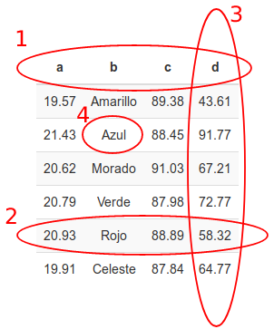

Fuente: Elaboración propia.

1. Encabezado (header)
2. Fila (row)
3. Columna (column)
4. Celda (cell)

# Partes de una base de datos **tabular** (II)

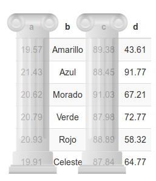

Fuente: Elaboración propia.

# La base de datos ideal: tidy

- En el paradigma “tidy” [(Wickham, 2014)](https://docs.google.com/viewer?url=https://www.jstatsoft.org/index.php/jss/article/view/v059i10/v59i10.pdf):
  1. Cada variable es una columna
  2. Cada observación es una fila
  3. Cada valor es una celda
  4. Existe una base de datos para cada unidad observacional

# Ejercicio 1

- Favor ir a la [hoja de ruta](https://docs.google.com/document/d/1Y0m0ExZfTO0EZe9JTGVOesNSWqiqnQFMAwCXhmHvzpA/edit?usp=sharing). y abrir el primer ejercicio.
- Contiene un panel para las emisiones anuales de CO2 de los países americanos (unidad de medida: toneladas per capita).
- Hay tres bases con la misma información, una por cada hoja. ¿Cuál es la “tidy”?

# Operaciones básicas en base de datos [(Wickham, 2014)](https://docs.google.com/viewer?url=https://www.jstatsoft.org/index.php/jss/article/view/v059i10/v59i10.pdf)

- Transformar columnas (añadir o modificar existentes)
  - Puede ser en una sola columna o en múltiples columnas
  - En el tidyverse, `mutate()`
- Seleccionar columnas (y excluir otras)
  - En el tidyverse, `select()`
- Filtrar observaciones en base a una condición
  - En el tidyverse, `filter()`
- Ordenar la base de datos, en base a una(s) variable(s)
  - En el tidyverse, `arrange()`
- Agregar/colapsar la base de datos
  - Colapsar múltiples valores en algún resumen (por ejemplo, media o suma)
  - Puede ser para toda la base o por subgrupos
  - En el tidyverse, `summarize()`

# Ejercicio 2

- Favor ir a la [hoja de ruta](https://docs.google.com/document/d/1Y0m0ExZfTO0EZe9JTGVOesNSWqiqnQFMAwCXhmHvzpA/edit?usp=sharing). y abrir el segundo ejercicio.
- ¿Qué operaciones básicas podemos hacer para comenzar a analizar estos datos? Por favor contesta en la asistencia.